# Neural Activity Exploration Project

# What’s in the session?

```r
names(session[[1]])
```

```
## [1] "contrast_left"  "contrast_right" "feedback_type"  "mouse_name"
## [5] "brain_area"     "date_exp"       "spks"           "time"
```

# Table to see the overview of the dataframe

```r
n.session=length(session)

table <- tibble(
  mouse_name = rep('name',n.session),
  date_exp =rep('dt',n.session),
  n_brain_area = rep(0,n.session),
  n_neurons = rep(0,n.session),
  n_trials = rep(0,n.session),
  success_rate = rep(0,n.session)
)


for(i in 1:n.session){
  tmp = session[[i]];
  table[i,1]=tmp$mouse_name;
  table[i,2]=tmp$date_exp;
  table[i,3]=length(unique(tmp$brain_area));
  table[i,4]=dim(tmp$spks[[1]])[1];
  table[i,5]=length(tmp$feedback_type);
  table[i,6]=mean(tmp$feedback_type+1)/2;
  }

table
```

```
## # A tibble: 18 × 6
##    mouse_name date_exp   n_brain_area n_neurons n_trials success_rate
##    <chr>      <chr>             <dbl>     <dbl>    <dbl>        <dbl>
##  1 Cori       2016-12-14            8       734      114        0.605
##  2 Cori       2016-12-17            5      1070      251        0.633
##  3 Cori       2016-12-18           11       619      228        0.662
##  4 Forssmann  2017-11-01           11      1769      249        0.667
##  5 Forssmann  2017-11-02           10      1077      254        0.661
##  6 Forssmann  2017-11-04            5      1169      290        0.741
##  7 Forssmann  2017-11-05            8       584      252        0.671
##  8 Hench      2017-06-15           15      1157      250        0.644
##  9 Hench      2017-06-16           12       788      372        0.685
## 10 Hench      2017-06-17           13      1172      447        0.620
## 11 Hench      2017-06-18            6       857      342        0.795
## 12 Lederberg  2017-12-05           12       698      340        0.738
## 13 Lederberg  2017-12-06           15       983      300        0.797
## 14 Lederberg  2017-12-07           10       756      268        0.694
## 15 Lederberg  2017-12-08            8       743      404        0.765
## 16 Lederberg  2017-12-09            6       474      280        0.718
## 17 Lederberg  2017-12-10            6       565      224        0.830
## 18 Lederberg  2017-12-11           10      1090      216        0.806
```

# Show the percengtage of trial of success (feedback type)

```r
n.session=length(session)

n_success = 0
n_trial = 0
for(i in 1:n.session){
    tmp = session[[i]];
    n_trial = n_trial + length(tmp$feedback_type);
    n_success = n_success + sum(tmp$feedback_type == 1);
}
n_success/n_trial
```

```
## [1] 0.7100964
```

Around 71% of trials are success in this experiment

# How many levels in brain area?

```r
area = c()
for(i in 1:n.session){
    tmp = session[[i]];
    area = c(area, unique(tmp$brain_area))
}

area = unique(area)
length(area)
```

```
## [1] 62
```

There are 62 levels in brain area

# Preparing the data before PCA analysis

```r
all_sessions <- list()
for (i in 1:18) {
  all_sessions[[i]] <- data.frame(session_id = i,
                                  brain_area = session[[i]]$brain_area,
                                  spike_count = rowSums(session[[i]]$spks[[1]]))
}
df_spikes <- bind_rows(all_sessions)

df_avg_spikes <- df_spikes %>%
  group_by(session_id, brain_area) %>%
  summarize(avg_spikes = mean(spike_count, na.rm = TRUE), .groups = "drop")

df_pca <- df_avg_spikes %>%
  pivot_wider(names_from = brain_area, values_from = avg_spikes, values_fill = 0)

df_pca <- df_pca %>% mutate_if(is.character, as.numeric)

pca_data <- df_pca %>% select(-session_id)

pca_data <- pca_data[, apply(pca_data, 2, var) > 0]
```

# PCA performance for the neural spike data

```r
pca_result <- prcomp(pca_data, center = TRUE, scale. = TRUE)

pca_df <- as.data.frame(pca_result$x)
pca_df$session_id <- df_pca$session_id
```

# Plot for PCA clusters

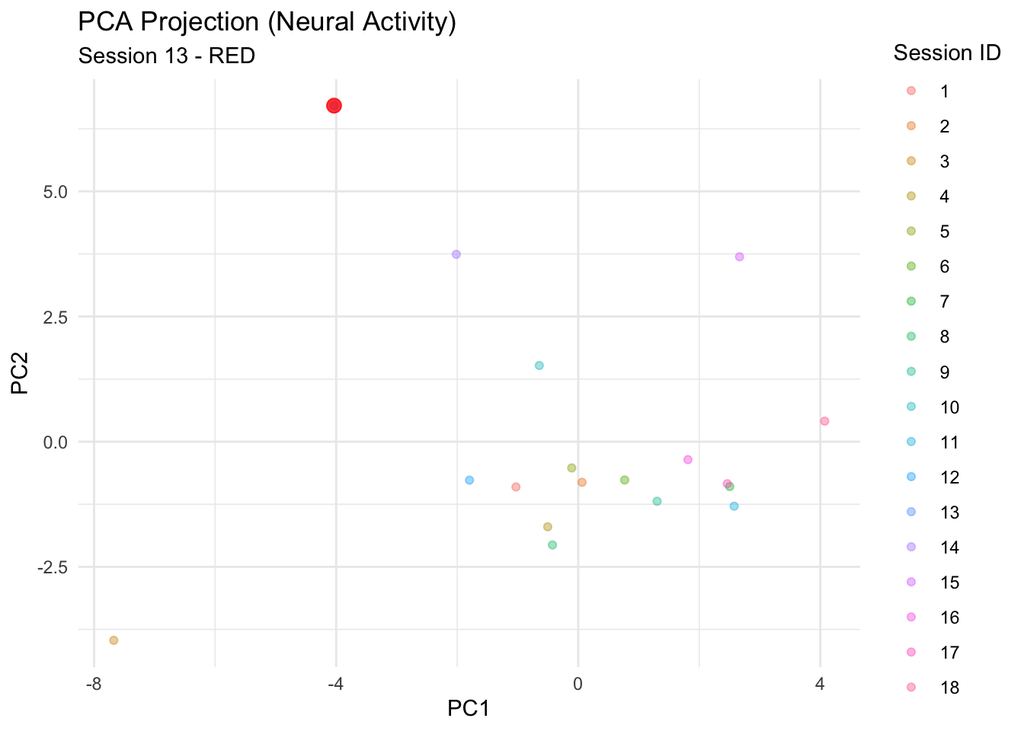

```r
ggplot(pca_df, aes(x = PC1, y = PC2, color = factor(session_id))) +
  geom_point(alpha = 0.4) +
  geom_point(data = pca_df %>% filter(session_id == 13),
             aes(x = PC1, y = PC2),
             color = "red",
             size = 3,
             alpha = 0.8) +
  theme_minimal() +
  labs(title = "PCA Projection (Neural Activity)",
       subtitle = "Session 13 - RED",
       x = "PC1",
       y = "PC2",
       color = "Session ID") +
  theme(legend.position = "right")
```

# Comparing session 13 to 17 in terms of spike distributions

Boxplot across brain areas to compare spike activity

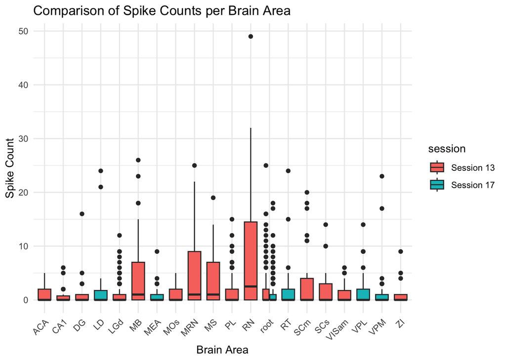

```r
library(ggplot2)

spike_13 <- data.frame(
  brain_area = session[[13]]$brain_area,
  spike_count = rowSums(session[[13]]$spks[[1]])
)

spike_17 <- data.frame(
  brain_area = session[[17]]$brain_area,
  spike_count = rowSums(session[[17]]$spks[[1]])
)

spike_13$session <- "Session 13"
spike_17$session <- "Session 17"
combined_data_spike <- rbind(spike_13, spike_17)

ggplot(combined_data_spike, aes(x = brain_area, y = spike_count, fill = session)) +
  geom_boxplot() +
  theme_minimal() +
  labs(title = "Comparison of Spike Counts per Brain Area",
       x = "Brain Area",
       y = "Spike Count") +
  theme(axis.text.x = element_text(angle = 45, hjust = 1))
```

Based on the plot, I suggest that Session 17 displayed less neural activity overall compared to Session 13.

The brain areas that show greater variability such as RN, PL, MS, MRN might be a part of behaviors which were more dominant during Session 13.

The less activity in Session 17 relative to Session 13 might be because of behavioral states or different experimental conditions.

Additional Visual to show the distint differnce between the two sessions

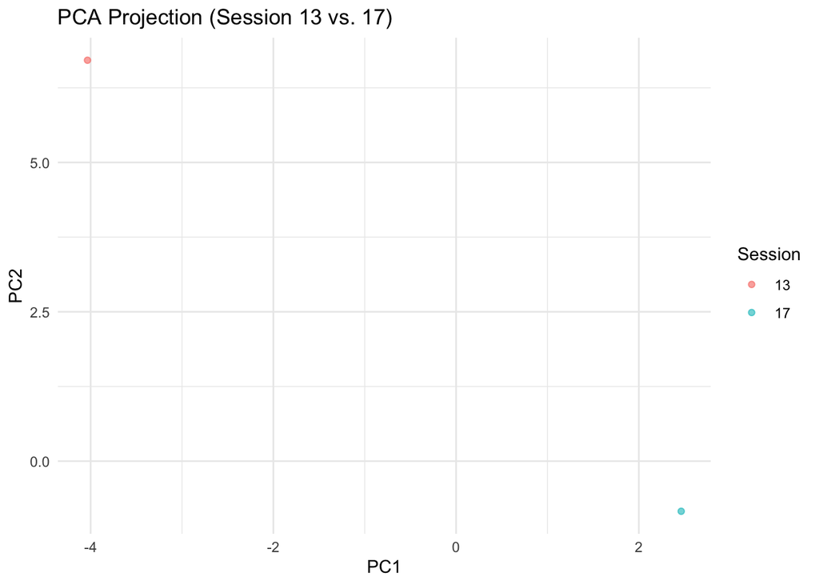

```r
pca_sessions <- pca_df %>% filter(session_id %in% c(13, 17))

ggplot(pca_sessions, aes(x = PC1, y = PC2, color = factor(session_id))) +
  geom_point(alpha = 0.6) +
  labs(title = "PCA Projection (Session 13 vs. 17)",
       x = "PC1",
       y = "PC2",
       color = "Session") +
  theme_minimal()
```

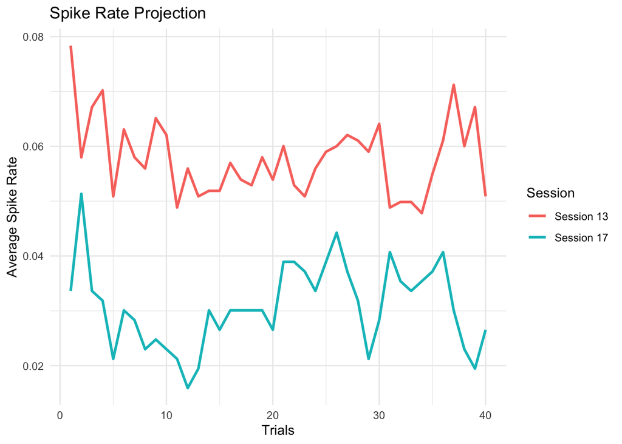

```r
s_13_spikes <- apply(session[[13]]$spks[[1]], 2, mean)
s_17_spikes <- apply(session[[17]]$spks[[1]], 2, mean)

spike_trend_df <- data.frame(
  Trial = 1:length(s_13_spikes),
  Session_13 = s_13_spikes,
  Session_17 = s_17_spikes
)

ggplot(spike_trend_df, aes(x = Trial)) +
  geom_line(aes(y = Session_13, color = "Session 13"), size = 1) +
  geom_line(aes(y = Session_17, color = "Session 17"), size = 1) +
  theme_minimal() +
  labs(title = "Spike Rate Projection",
       x = "Trials",
       y = "Average Spike Rate",
       color = "Session")
```

Correlation heatmaps of neural correlations in session 13 and 17

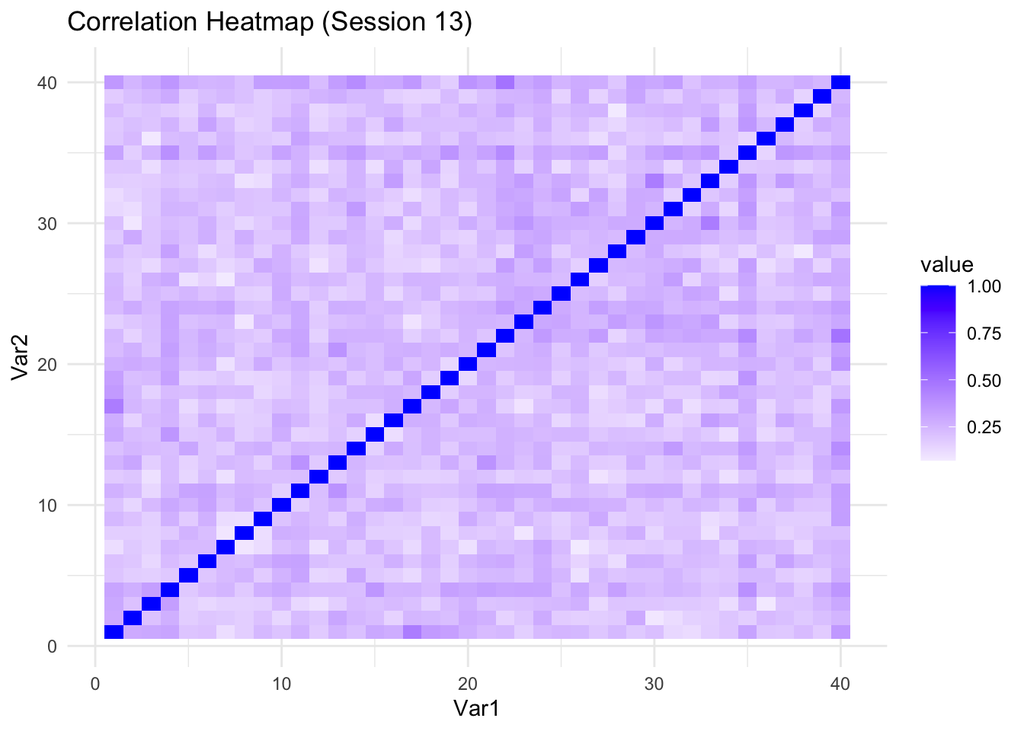

```r
corr_13 <- cor(session[[13]]$spks[[1]], use = "complete.obs")

library(reshape2)
corr_13_melted <- melt(corr_13)

ggplot(corr_13_melted, aes(Var1, Var2, fill = value)) +
  geom_tile() +
  scale_fill_gradient2(low = "red", high = "blue", mid = "white", midpoint = 0) +
  labs(title = "Correlation Heatmap (Session 13)") +
  theme_minimal()
```

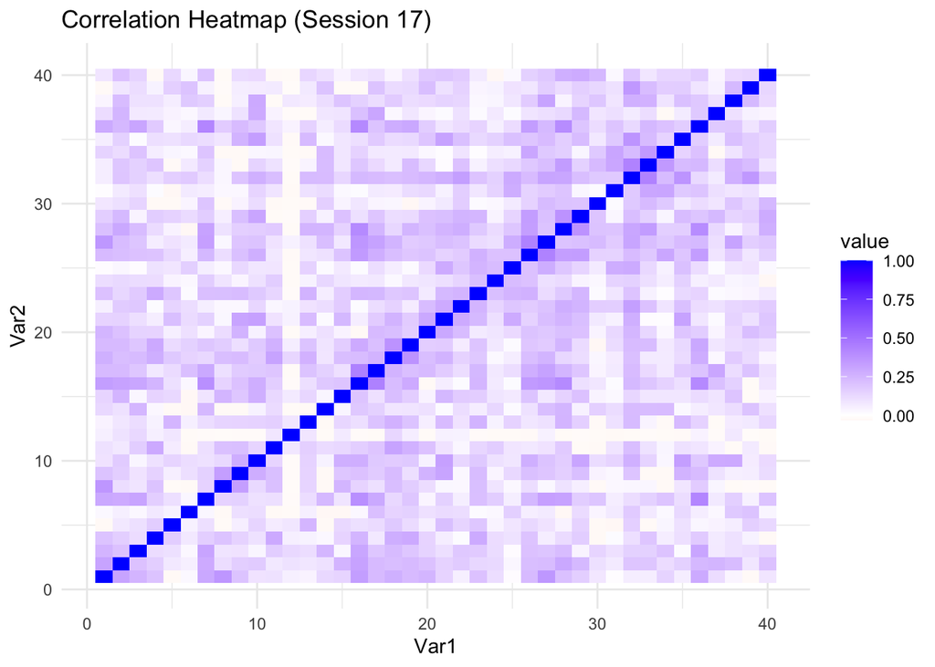

```r
corr_17 <- cor(session[[17]]$spks[[1]], use = "complete.obs")

corr_17_melted <- melt(corr_17)

ggplot(corr_17_melted, aes(Var1, Var2, fill = value)) +
  geom_tile() +
  scale_fill_gradient2(low = "red", high = "blue", mid = "white", midpoint = 0) +
  labs(title = "Correlation Heatmap (Session 17)") +
  theme_minimal()
```

Session 13 appears to have stronger correlations which align with the fact that we found from previous box plot, overall higher spike counts. It might be true that Session 13 had more interconnected and active brain activity.

# Define the dataframe session_13_17

```r
feedback_17 <- data.frame(
  session_id = 17,
  feedback = session[[17]]$feedback_type
)

feedback_13 <- data.frame(
  session_id = 13,
  feedback = session[[13]]$feedback_type
)

feedback_data <- rbind(feedback_13, feedback_17)

combined <- pca_df %>% filter(session_id %in% c(13, 17))

combined <- left_join(combined, feedback_data, by = "session_id")

str(combined)
```

```
## 'data.frame':    524 obs. of  20 variables:
##  $ PC1       : num  -4.03 -4.03 -4.03 -4.03 -4.03 ...
##  $ PC2       : num  6.71 6.71 6.71 6.71 6.71 ...
##  $ PC3       : num  1.55 1.55 1.55 1.55 1.55 ...
##  $ PC4       : num  1.12 1.12 1.12 1.12 1.12 ...
##  $ PC5       : num  -0.252 -0.252 -0.252 -0.252 -0.252 ...
##  $ PC6       : num  -1.72 -1.72 -1.72 -1.72 -1.72 ...
##  $ PC7       : num  -2.05 -2.05 -2.05 -2.05 -2.05 ...
##  $ PC8       : num  2.48 2.48 2.48 2.48 2.48 ...
##  $ PC9       : num  -0.186 -0.186 -0.186 -0.186 -0.186 ...
##  $ PC10      : num  -1.59 -1.59 -1.59 -1.59 -1.59 ...
##  $ PC11      : num  -1.61 -1.61 -1.61 -1.61 -1.61 ...
##  $ PC12      : num  1.23 1.23 1.23 1.23 1.23 ...
##  $ PC13      : num  0.163 0.163 0.163 0.163 0.163 ...
##  $ PC14      : num  0.738 0.738 0.738 0.738 0.738 ...
##  $ PC15      : num  -0.0332 -0.0332 -0.0332 -0.0332 -0.0332 ...
##  $ PC16      : num  0.209 0.209 0.209 0.209 0.209 ...
##  $ PC17      : num  -0.184 -0.184 -0.184 -0.184 -0.184 ...
##  $ PC18      : num  -8.84e-17 -8.84e-17 -8.84e-17 -8.84e-17 -8.84e-17 ...
##  $ session_id: num  13 13 13 13 13 13 13 13 13 13 ...
##  $ feedback  : num  -1 1 1 1 1 1 1 1 1 1 ...
```

Bar plot for the distribution of feedback types for session 13 and 17

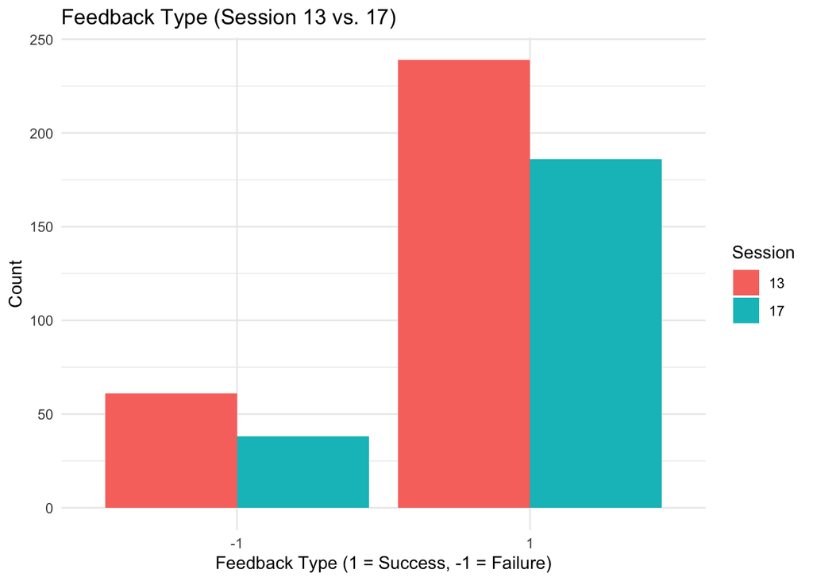

```r
library(ggplot2)
combined %>%
  group_by(session_id, feedback) %>%
  summarise(count = n(), .groups = "drop") %>%
  ggplot(aes(x = factor(feedback), y = count, fill = factor(session_id))) +
  geom_bar(stat = "identity", position = "dodge") +
  labs(title = "Feedback Type (Session 13 vs. 17)",
       x = "Feedback Type (1 = Success, -1 = Failure)",
       y = "Count",
       fill = "Session") +
  theme_minimal()
```

# Preparing data for logistic regression, employing benchmark method 1

**Benchmark method 1** - Summarizing brain_area, spks, and time into a single number by getting the average over spks

```r
n_obs = length(session[[13]]$feedback_type)

dat = tibble(
    feedback_type = as.factor(session[[13]]$feedback_type),
    decision = rep('name', n_obs),
    avg_spikes = rep(0, n_obs)
)

for (i in 1:n_obs){
    # decision
    if (session[[13]]$contrast_left[i] > session[[13]]$contrast_right[i]){
        dat$decision[i] = '1'
    } else if (session[[13]]$contrast_left[i] < session[[13]]$contrast_right[i]){
        dat$decision[i] = '2'
    } else if (session[[13]]$contrast_left[i] == session[[13]]$contrast_right[i]
               & session[[13]]$contrast_left[i] == 0){
        dat$decision[i] = '3'
    } else{
        dat$decision[i] = '4'
    }

    # avg_spks
    spks.trial = session[[13]]$spks[[i]]
    total.spikes = apply(spks.trial, 1, sum)
    dat$avg_spikes[i] = mean(total.spikes)
}

dat$decision = as.factor(dat$decision)
summary(dat)
```

```
##  feedback_type decision   avg_spikes
##  -1: 61        1:112    Min.   :1.992
##  1 :239        2: 91    1st Qu.:2.332
##                3: 82    Median :2.444
##                4: 15    Mean   :2.458
##                         3rd Qu.:2.567
##                         Max.   :2.972
```

# Prediction model 1

Splitting the data into train(80%) and test set(20%)

```r
set.seed(101)
sample <- sample.int(n = n_obs, size = floor(.8 * n_obs), replace = F)
train <- dat[sample, ]
test  <- dat[-sample, ]
```

Model training

```r
fit1 <- glm(feedback_type~., data = train, family="binomial")
summary(fit1)
```

```
##
## Call:
## glm(formula = feedback_type ~ ., family = "binomial", data = train)
##
## Coefficients:
##             Estimate Std. Error z value Pr(>|z|)
## (Intercept)  2.69252    2.54834   1.057  0.29071
## decision2   -0.51032    0.55331  -0.922  0.35637
## decision3   -2.08279    0.46964  -4.435 9.21e-06 ***
## decision4   -1.92392    0.74019  -2.599  0.00934 **
## avg_spikes  -0.08551    1.03674  -0.082  0.93426
## ---
## Signif. codes:  0 '***' 0.001 '**' 0.01 '*' 0.05 '.' 0.1 ' ' 1
##
## (Dispersion parameter for binomial family taken to be 1)
##
##     Null deviance: 234.54  on 239  degrees of freedom
## Residual deviance: 205.78  on 235  degrees of freedom
## AIC: 215.78
##
## Number of Fisher Scoring iterations: 5
```

```r
pred1 <- predict(fit1, test %>% select(-feedback_type), type = 'response')

prediction1 <- factor(ifelse(pred1 > 0.5, "1", "-1"), levels = levels(test$feedback_type))

mean(prediction1 != test$feedback_type)
```

```
## [1] 0.25
```

```r
if (!any(is.na(pred1))) {
  pr = prediction(pred1, test$feedback_type)
  prf <- performance(pr, measure = "tpr", x.measure = "fpr")
}
```

The prediction error on the test data set is around 25%

```r
if (!any(is.na(pred1))) {
  pr = prediction(pred1, test$feedback_type)
  prf <- performance(pr, measure = "tpr", x.measure = "fpr")
}
```

```r
table(session[[13]]$brain_area)
```

```
##
##   ACA   CA1    DG   LGd    MB   MOs   MRN    MS    PL    RN  root   SCm   SCs
##    58    34    17   150    63    46    51    23   184    58   173    45    32
## VISam    ZI
##    34    15
```

# Average Number of Spikes across brain areas

```r
spike_13 <- data.frame(
  brain_area = session[[13]]$brain_area,
  spike_count = rowSums(session[[13]]$spks[[1]])
)

avg_13 <- spike_13 %>%
  group_by(brain_area) %>%
  summarise(avg_spikes = mean(spike_count, na.rm = TRUE)) %>%
  arrange(desc(avg_spikes))

summary(avg_13)
```

```
##   brain_area          avg_spikes
##  Length:15          Min.   :0.6176
##  Class :character   1st Qu.:1.0808
##  Mode  :character   Median :1.7052
##                     Mean   :2.5562
##                     3rd Qu.:3.5754
##                     Max.   :8.2759
```

Bar chart

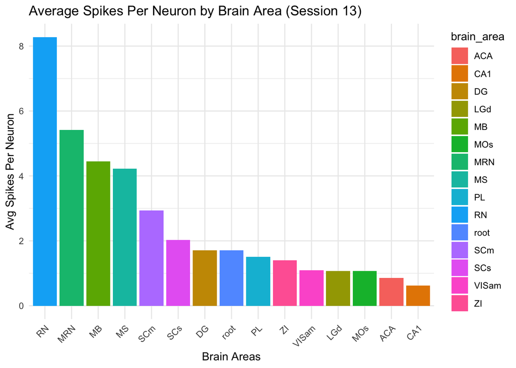

```r
ggplot(avg_13, aes(x = reorder(brain_area, -avg_spikes), y = avg_spikes, fill = brain_area)) +
  geom_bar(stat = "identity") +
  theme_minimal() +
  labs(title = "Average Spikes Per Neuron by Brain Area (Session 13)",
       x = "Brain Areas", y = "Avg Spikes Per Neuron") +
  theme(axis.text.x = element_text(angle = 45, hjust = 1))
```

The RN, MRN, and MB appear to have the top 3 highest neural activity. This finding can suggest that these brain areas are most likely involved in motor control, cognitivie processing, and coordination during the session.

The lower side of average spikes per neuron such as CA1 and ACA might suggest their low engagement in the specific task

```r
avg_spike_area<-function(i.t,this_session){
  spk.trial = this_session$spks[[i.t]]
  area= this_session$brain_area
  spk.count=apply(spk.trial,1,sum)
  spk.average.tapply=tapply(spk.count, area, mean)
  return(spk.average.tapply)
}
```

Table

```r
n_area = length(unique(session[[13]]$brain_area))
area_spk = matrix(rep(0, n_obs * n_area), n_obs, n_area)
for (i in 1:n_obs){
    area_spk[i,] = avg_spike_area(i, session[[13]])
}

area_spk = as_tibble(area_spk)
colnames(area_spk)= unique(session[[13]]$brain_area)
dat1 = bind_cols(dat, area_spk) %>% select(-avg_spikes)
head(dat1)
```

```
## # A tibble: 6 × 17
##   feedback_type decision VISam    ZI    DG   CA1   LGd    MB   SCs    RN   MRN
##   <fct>         <fct>    <dbl> <dbl> <dbl> <dbl> <dbl> <dbl> <dbl> <dbl> <dbl>
## 1 -1            3        0.862 0.618  1.71  1.07  4.44  1.07  5.41  4.22  1.51
## 2 1             3        1.05  0.765  2.18  1.33  3.86  1.17  4.49  4.96  1.64
## 3 1             1        1.5   1.03   1.94  2.16  4.44  1.74  4.80  4.52  1.78
## 4 1             3        1.29  1      2.06  1.46  3.68  1.07  4.88  3.83  1.39
## 5 1             3        1.34  0.765  1.71  1.61  4.02  1.22  5.14  3.65  1.59
## 6 1             1        1.36  0.824  1.35  2.04  3.94  1.93  4.35  4.74  2.05
## # ℹ 6 more variables: SCm <dbl>, ACA <dbl>, PL <dbl>, MS <dbl>, root <dbl>,
## #   MOs <dbl>
```

# Prediction Model 2

Splitting data into train(80%) and test(20%) set

```r
set.seed(101)
sample <- sample.int(n = n_obs, size = floor(.8 * n_obs), replace = F)
train <- dat1[sample, ]
test  <- dat1[-sample, ]
```

Model training

```r
fit2 <- glm(feedback_type~., data = train, family="binomial")
summary(fit2)
```

```
##
## Call:
## glm(formula = feedback_type ~ ., family = "binomial", data = train)
##
## Coefficients:
##             Estimate Std. Error z value Pr(>|z|)
## (Intercept)  0.19674    3.29435   0.060  0.95238
## decision2   -0.94626    0.65851  -1.437  0.15072
## decision3   -2.11289    0.61652  -3.427  0.00061 ***
## decision4   -2.49050    0.83474  -2.984  0.00285 **
## VISam       -0.77901    0.93894  -0.830  0.40673
## ZI           0.96993    0.83807   1.157  0.24713
## DG           0.24608    0.34327   0.717  0.47345
## CA1          0.07198    0.88868   0.081  0.93544
## LGd         -0.15344    0.44126  -0.348  0.72804
## MB          -0.42793    0.87545  -0.489  0.62497
## SCs         -0.46520    0.38086  -1.221  0.22191
## RN          -0.19543    0.27056  -0.722  0.47010
## MRN         -0.47874    1.32107  -0.362  0.71706
## SCm          0.81026    0.31076   2.607  0.00913 **
## ACA          0.32944    1.39825   0.236  0.81374
## PL          -0.35122    0.37862  -0.928  0.35359
## MS           0.17250    0.43423   0.397  0.69118
## root         0.62630    0.90930   0.689  0.49096
## MOs         -0.24959    0.33165  -0.753  0.45171
## ---
## Signif. codes:  0 '***' 0.001 '**' 0.01 '*' 0.05 '.' 0.1 ' ' 1
##
## (Dispersion parameter for binomial family taken to be 1)
##
##     Null deviance: 234.54  on 239  degrees of freedom
## Residual deviance: 184.65  on 221  degrees of freedom
## AIC: 222.65
##
## Number of Fisher Scoring iterations: 5
```

```r
pred2 <- predict(fit2, test %>% select(-feedback_type), type = 'response')
prediction2 <- factor(ifelse(pred2 > 0.5, "1", "-1"), levels = c("-1", "1"))
mean(prediction2 != test$feedback_type)
```

```
## [1] 0.2166667
```

The prediction error is about 22%, which is lower than the first model

# ROC Curve

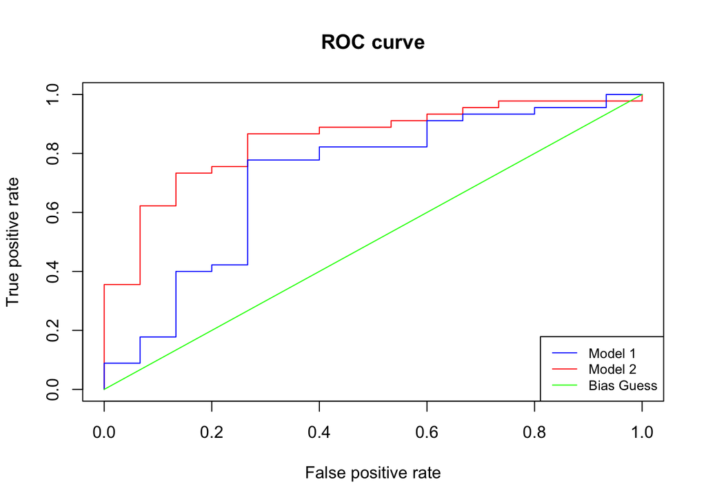

```r
pr = prediction(pred1, test$feedback_type)
prf <- performance(pr, measure = "tpr", x.measure = "fpr")
auc <- performance(pr, measure = "auc")
auc <- auc@y.values[[1]]

pr = prediction(pred2, test$feedback_type)
prf2 <- performance(pr, measure = "tpr", x.measure = "fpr")
auc2 <- performance(pr, measure = "auc")
auc2 <- auc2@y.values[[1]]

pred0 = pred1 * 0 + 1
pr = prediction(pred0, test$feedback_type)
prf0 <- performance(pr, measure = "tpr", x.measure = "fpr")
auc0 <- performance(pr, measure = "auc")
auc0 <- auc0@y.values[[1]]

plot(prf2, ,col = 'red', main = 'ROC curve')
plot(prf, add = TRUE, col = 'blue')
plot(prf0, add = TRUE, col = 'green')
legend("bottomright", legend=c("Model 1", "Model 2", "Bias Guess"), col=c("blue", "red", 'green'), lty=1:1,
       cex=0.8)
```

# AUC

```r
print(c(auc, auc2, auc0))
```

```
## [1] 0.7200000 0.8459259 0.5000000
```

Based on AUC, model 2 performed better than model 1

# Discussion

First of all, the PCA results suggests that session 13 has distinct clustering patterns compared to other sessions, potentially indicating differences in neural activity distribution. The comparison made between session 13 and 17 using the direct comparison of spike distributions and PCA projects reveals variations in neural firing rates across brain regions. For the predictive model built using logistic regression model, the model trained on neural data showed a moderate performance to classify feedback type based on spike activity possibly suggesting some brain regions may be critical in decision making process.

The exact reason for unique clustering of session 13 remains unclear. Hypothetically, if session 13 keeps showing different neural patterns, it could be due to learning effect or other experimental conditions. For further investigation, we could try to conduct additional feature selection in PCA.

What is PC score? It is the value that places each data point’s position along the newly defined axes that catches the most variance after PCA adjusts the original data from the data with high dimensions

The PC1 explains the largest variance while PC2 explains the second-largest